# Ecercice 1:

```python
from numpy import prod
def prog(x,y,c):
    S = []
    n = len(x)

    for j in range(n):
        L =[c-xx for xx in x]
        for k in range(n):
            if (k == j):
                L[k] = 1
            else:
                L[k] = L[k]/(x[j] - x[k])
        S.append(y[j]*prod(L))

    return  sum(S)
```

```python
X=[1 ,2 ,3 ,4,-2]
Y=[-1, 0, 2 ,1,3]
for i in X:
    print(prog(X,Y,i))
sum(X)
```

```
-1.0
0.0
2.0
1.0
3.0
```

```
8
```

**Polynome d'interpolation de Lagrange**

Soient $(x_0,y_0), \ldots,(x_k,y_k),\ldots ,(x_n,k_n)$ $n+1$ points deux à deux distincts, le polynôme d'interpolation de Lagrange associés à ces points supports est défini par :$$P_n(x)=\sum_{k=0}^{n-1} y_kL_k(x)$$

avec $L_{0}(x)=\displaystyle\frac{(x-x_1)(x-x_2)\ldots(x-x_{n})}{(x_0-x_1)(x_0-x_2)\ldots(x_0-x_{n})}$ et $L_{k}(x)=\displaystyle\frac{(x-x_1)(x-x_2)\ldots(x-x_{k-1})(x-x_{k+1})\ldots(x_0-x_{n})}{(x_k-x_0)(x_k-x_1)\ldots(x_k-x_{k-1})(x_k-x_{k+1})\ldots(x_k-x_{n})}$ pour $k\in \{1,\ldots,n\}$

```python
from numpy import prod

def PR(x,y,c):
   S = []
   n = len(x)

   for j in range(n):
        L =[c-xx for xx in x]
        for k in range(n):
            if (k == j):
                L[k] = 1
            else:
                L[k] = L[k]/(x[j] - x[k])
        S.append(y[j]*prod(L))

   return  sum(S)
```

```python
X=[1, 2, 3, 4]
Y=[-1, 0, 2, 1]
for i in X:
  print(PR(X,Y,i))
```

```
-1.0
0.0
2.0
1.0
```

2)Que contient le vecteur LL après la fin de la boucle kk

```python
x=[1, 2, 3, 4]
y=[-1, 0, 2, 1]
```

```python
 S = []
 n = len(x)
 for c in (X):

  for j in range(n):
      L =[c-xx for xx in x]
      for k in range(n):
            if (k == j):
                L[k] = 1
            else:
                L[k] = L[k]/(x[j] - x[k])
      S.append(y[j]*prod(L))

 print (sum(S))
```

```
2.0
```

```python
L
```

```
[1.0, 1.0, 1.0, 1]
```

3° 3) Utiliser cette fonction pour dessiner le graph du polynôme de Lagrange de la fonction $f(x) = \dfrac{1}{1 + x^2}$ aux points $x=[-1:0.1:1]$.

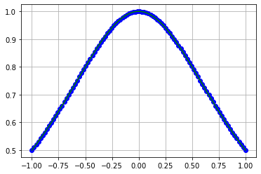

```python
import matplotlib.pyplot as plt
from numpy import linspace
import numpy as np

x=[-1, 0.1, 1]
x=np.linspace(-1,1,100)
f = lambda x: 1/(1+x**2)
y=f(x)
t=np.linspace(-1,1,100)
pt=[]
for u in t:
    pt.append(PR(x,y,u))

plt.plot(t,pt,'r',x,y,'bo',t,f(t),'g')
plt.grid(True)
plt.show()
```

4.1) Représenter sur un même graphe la fonction $F$ et $p_n$, où $p_n$ est le polynôme d'interpolation de Lagrange de $F$ aux points $x_0,\,\ldots,\,x_n$

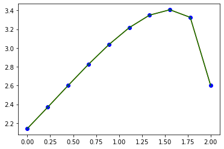

```python
import matplotlib.pyplot as plt
from math import *
from numpy import linspace
import numpy as np

x=np.linspace(0,2,10)

f=lambda x: np.pi-np.cos(x/2)+x*np.sqrt(1-(x/2)**2)
y=f(x)
t=np.linspace(0,2,10)
pn=[]
for u in t:
    pn.append(PR(x,y,u))


plt.plot(t,pn,'r',x,y,'bo',t,f(t),'g')
plt.show ()
```

2)Tracer la courbe d'erreur (la fonction $F-p_n$). Qu'observer vous.

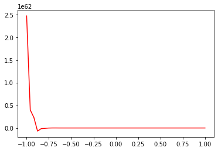

```python
import matplotlib.pyplot as plt
from math import *
from numpy import linspace
import numpy as np

x=np.linspace(0.75,1,50)
f=lambda x: np.pi-np.cos(x/2)+x*np.sqrt(1-(x/2)**2)
y=f(x)
t=linspace(-1,1)
pn=[]
for u in t:
    pn.append(PR(x,y,u))

plt.plot(t,f(t)-pn,'r')
plt.show()
```

# Ecercice2:

**Phenomène de Runge**

```python
import matplotlib.pyplot as plt
from numpy import linspace
import numpy as np
```

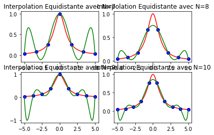

```python
import matplotlib.pyplot as plt
from numpy import linspace
import numpy as np
N=7
X=linspace(-5,5,N)
f=lambda x: 1/(1+x**2)
Y=f(X)
p=np.polyfit(X,Y,N-1)
t=linspace(-5,5,1000)
plt.subplot(2,2,1)
plt.plot(t,f(t),'r',X,Y,'ob', t, np.polyval(p,t),'g')
plt.title("Interpolation Equidistante avec N=7")
#####################################################
N=8
X=linspace(-5,5,N)
f=lambda x: 1/(1+x**2)
Y=f(X)
p=np.polyfit(X,Y,N-1)
t=linspace(-5,5,1000)
plt.subplot(2,2,2)
plt.plot(t,f(t),'r',X,Y,'ob', t, np.polyval(p,t),'g')
plt.title("Interpolation Equidistante avec N=8")
#######################################################
N=9
X=linspace(-5,5,N)
f=lambda x: 1/(1+x**2)
Y=f(X);
p=np.polyfit(X,Y,N-1)
t=linspace(-5,5,1000)
plt.subplot(2,2,3)
plt.plot(t,f(t),'r',X,Y,'ob', t, np.polyval(p,t),'g')
plt.title("Interpolation Equidistante avec N=9")
#######################################################
N=10
X=linspace(-5,5,N)
f=lambda x: 1/(1+x**2)
Y=f(X);
p=np.polyfit(X,Y,N-1)
t=linspace(-5,5,1000)
plt.subplot(2,2,4)
plt.plot(t,f(t),'r',X,Y,'ob', t, np.polyval(p,t),'g')
plt.title("Interpolation Equidistante avec N=10")
```

2) Les points de Tchebycheff sur un intervalle $[a;b]$ sont définie par :$$x_k=\dfrac{a+b}{2}+\dfrac{a-b}{2}\cos\left(\frac{k-1}{n-1}\pi\right)\hspace{0.5cm} (k=1,..,n: x_1=a:x_n=b)$$

Vérifier que sur $[-5; 5]$ ; l'interpolation polynômiale de $f(x) = \dfrac{1}{1 + x^2}$ ; en $N$ points de Tchebychev est meilleure qu'une interpolation utilisant $N$ points uniforment espacés (on prendra $N=10, 11, 16, 17$).

```python
import math
import numpy as np
def tcheb (a,b,n):
  V=[]
  for k in range (1,n):
    V.append((a+b)/2+(a-b)/2*math.cos((k-1)/(n-1)*math.pi))
  return V
```

```python
tcheb(-5,5,11)
```

```
[-5.0,
 -4.755282581475767,
 -4.045084971874737,
 -2.938926261462366,
 -1.5450849718747373,
 -3.061616997868383e-16,
 1.5450849718747368,
 2.938926261462365,
 4.045084971874736,
 4.755282581475767]
```

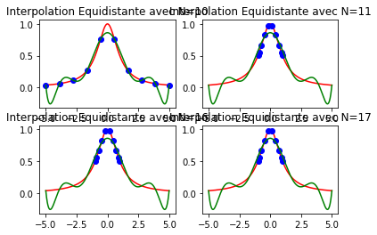

```python
import matplotlib.pyplot as plt
from numpy import linspace
import numpy as np
N=10
Xt=np.polynomial.chebyshev.Chebyshev(np.array([0]*10+[1])).roots()
f= lambda x: 1/(1 + x**2)
Yt=f(Xt)
pt=np.polyfit(Xt,Yt,N-1)

plt.subplot(2,2,1)
plt.plot(t,f(t),'r',X,Y,'ob', t, np.polyval(p,t),'g')
plt.title("Interpolation Equidistante avec N=10")
#####################################################
N=11
Xt=np.polynomial.chebyshev.Chebyshev(np.array([0]*10+[1])).roots()
f=lambda x: 1/(1+ x**2)
Yt=f(Xt)
pt=np.polyfit(Xt,Yt,N-1)
plt.subplot(2,2,2)
plt.plot(t,f(t),'r',Xt,Yt,'ob', t,np.polyval(p,t),'g')
plt.title("Interpolation Equidistante avec N=11")
#######################################################
N=16
Xt=np.polynomial.chebyshev.Chebyshev(np.array([0]*10+[1])).roots()
f=lambda x: 1/(1+x**2)
Yt=f(Xt);
pt=np.polyfit(Xt,Yt,N-1)
t=linspace(-5,5,1000)
plt.subplot(2,2,3)
plt.plot(t,f(t),'r',Xt,Yt,'ob', t, np.polyval(p,t),'g')
plt.title("Interpolation Equidistante avec N=16")
#######################################################
Xt=np.polynomial.chebyshev.Chebyshev(np.array([0]*10+[1])).roots()
f=lambda x: 1/(1+x**2)
Yt=f(Xt);
pt=np.polyfit(Xt,Yt,N-1)
t=linspace(-5,5,1000)
plt.subplot(2,2,4)
plt.plot(t,f(t),'r',Xt,Yt,'ob', t, np.polyval(p,t),'g')
plt.title("Interpolation Equidistante avec N=17")
```

```python
Exercice 3
```

```python
function f=intN(x,y)
m=length(x);
    for k=2:m
    f(k:m)=(y(k:m)-y(k-1:m-1))./(x(k:m)-x(1:m+1-k));
    end
end
```

```
  File "C:\Users\pcpc\AppData\Local\Temp/ipykernel_5020/2947840660.py", line 1
    function f=intN(x,y)
             ^
SyntaxError: invalid syntax
```

```python
x=[-1,0,2,5];
y=[6,1,3,66];
f=intN(x,y)
```

```python
function p=intNval(x,y,t)
m=length(x);
p=y(m)*ones(size(t));
for k=m-1:-1:1
    p=p.*(t-x(k))+y(k);
end
end
```

```python
x=[-1,0,2,5];
y=[6,1,3,66];
t=[0,1,2,3];
f=intNval(x,y,t)
```

```python
##Calcul a la main
```

[output not shown]